# SeqMonk Vistory Report

Data Set Renamed

lane1_D1_3_TKO_D0.1_2iL_TGTATGCG_L001_3536STDY8289528_GRCm38_hisat2.bam changed to D1_3_TKO_D0.1_2iL

Data Set Renamed

lane1_D1_3_TKO_D0.2_2iL_TCATTGAG_L001_3536STDY8289529_GRCm38_hisat2.bam changed to D1_3_TKO_D0.2_2iL

Data Set Renamed

lane1_D1_3_TKO_D0.3_2iL_TGGCTCAG_L001_3536STDY8289530_GRCm38_hisat2.bam changed to D1_3_TKO_D0.3_2iL

Data Set Renamed

lane1_D1_3_TKO_D1.1_EL_TATGCCAG_L001_3536STDY8289531_GRCm38_hisat2.bam changed to D1_3_TKO_D1.1_EL

Data Set Renamed

lane1_D1_3_TKO_D1.2_EL_TCAGATTC_L001_3536STDY8289532_GRCm38_hisat2.bam changed to D1_3_TKO_D1.2_EL

Data Set Renamed

lane1_D1_3_TKO_D1.3_EL_TACTAGTC_L001_3536STDY8289533_GRCm38_hisat2.bam changed to D1_3_TKO_D1.3_EL

Data Set Renamed

lane1_D1_3_TKO_D2.1_EL_TTCAGCTC_L001_3536STDY8289534_GRCm38_hisat2.bam changed to D1_3_TKO_D2.1_EL

Data Set Renamed

lane1_D1_3_TKO_D2.2_EL_TGTCTATC_L001_3536STDY8289535_GRCm38_hisat2.bam changed to D1_3_TKO_D2.2_EL

Data Set Renamed

lane1_D1_3_TKO_D2.3_EL_TATGTGGC_L001_3536STDY8289536_GRCm38_hisat2.bam changed to D1_3_TKO_D2.3_EL

Data Set Renamed

lane1_D1_3_WT_D0.1_2iL_TTGGTATG_L001_3536STDY8289519_GRCm38_hisat2.bam changed to D1_3_WT_D0.1_2iL

Data Set Renamed

lane1_D1_3_WT_D0.2_2iL_TGAACTGG_L001_3536STDY8289520_GRCm38_hisat2.bam changed to D1_3_WT_D0.2_2iL

Data Set Renamed

lane1_D1_3_WT_D1.1_EL_TACTTCGG_L001_3536STDY8289522_GRCm38_hisat2.bam changed to D1_3_WT_D1.1_EL

Data Set Renamed

lane1_D1_3_WT_D1.3_EL_TCTCACGG_L001_3536STDY8289524_GRCm38_hisat2.bam changed to D1_3_WT_D1.3_EL

Data Set Renamed

lane1_D1_3_WT_D2.1_EL_TCAGGAGG_L001_3536STDY8289525_GRCm38_hisat2.bam changed to D1_3_WT_D2.1_EL

Data Set Renamed

lane1_D1_3_WT_D2.2_EL_TAAGTTCG_L001_3536STDY8289526_GRCm38_hisat2.bam changed to D1_3_WT_D2.2_EL

Data Set Renamed

lane1_D1_3_WT_D2.3_EL_TCCAGTCG_L001_3536STDY8289527_GRCm38_hisat2.bam changed to D1_3_WT_D2.3_EL

Data Set Renamed

lane1_Dnmt1_3ab_TKO_D2.2_TTGACTCT_L001_3536STDY8289508_GRCm38_hisat2.bam changed to Dnmt1_3ab_TKO_D2.2

Data Set Renamed

lane1_Dnmt1_3ab_TKO_D2.3_TGCGATCT_L001_3536STDY8289509_GRCm38_hisat2.bam changed to Dnmt1_3ab_TKO_D2.3

Data Set Renamed

lane1_Dnmt1_3ab_TKO_D4.1_TTCCTGCT_L001_3536STDY8289510_GRCm38_hisat2.bam changed to Dnmt1_3ab_TKO_D4.1

Data Set Renamed

lane1_Dnmt1_3ab_TKO_D4.2_TAGTGACT_L001_3536STDY8289511_GRCm38_hisat2.bam changed to Dnmt1_3ab_TKO_D4.2

Data Set Renamed

lane1_Dnmt1_3ab_TKO_D4.3_TACAGGAT_L001_3536STDY8289512_GRCm38_hisat2.bam changed to Dnmt1_3ab_TKO_D4.3

Data Set Renamed

lane1_Dnmt1_3ab_TKO_D6.1_TCCTCAAT_L001_3536STDY8289513_GRCm38_hisat2.bam changed to Dnmt1_3ab_TKO_D6.1

Data Set Renamed

lane1_Dnmt1_3ab_TKO_D6.2_TGTGGTTG_L001_3536STDY8289514_GRCm38_hisat2.bam changed to Dnmt1_3ab_TKO_D6.2

Data Set Renamed

lane1_Dnmt1_3ab_TKO_D6.3_TAGTCTTG_L001_3536STDY8289515_GRCm38_hisat2.bam changed to Dnmt1_3ab_TKO_D6.3

Data Set Renamed

lane1_Dnmt1_3ab_TKO_D8.1_TTCCATTG_L001_3536STDY8289516_GRCm38_hisat2.bam changed to Dnmt1_3ab_TKO_D8.1

Data Set Renamed

lane1_Dnmt1_3ab_TKO_D8.2_TCGAAGTG_L001_3536STDY8289517_GRCm38_hisat2.bam changed to Dnmt1_3ab_TKO_D8.2

Data Set Renamed

lane1_Dnmt1_3ab_TKO_D8.3_TAACGCTG_L001_3536STDY8289518_GRCm38_hisat2.bam changed to Dnmt1_3ab_TKO_D8.3

Data Set Renamed

lane1_Dnmt1_3ab_WT_D2.1_TGGTTGTT_L001_3536STDY8289495_GRCm38_hisat2.bam changed to Dnmt1_3ab_WT_D2.1

Data Set Renamed

lane1_Dnmt1_3ab_WT_D2.2_TCTCGGTT_L001_3536STDY8289496_GRCm38_hisat2.bam changed to Dnmt1_3ab_WT_D2.2

Data Set Renamed

lane1_Dnmt1_3ab_WT_D2.3_TAAGCGTT_L001_3536STDY8289497_GRCm38_hisat2.bam changed to Dnmt1_3ab_WT_D2.3

Data Set Renamed

lane1_Dnmt1_3ab_WT_D4.1_TCCGTCTT_L001_3536STDY8289498_GRCm38_hisat2.bam changed to Dnmt1_3ab_WT_D4.1

Data Set Renamed

lane1_Dnmt1_3ab_WT_D4.2_TGTACCTT_L001_3536STDY8289499_GRCm38_hisat2.bam changed to Dnmt1_3ab_WT_D4.2

Data Set Renamed

lane1_Dnmt1_3ab_WT_D6.1_TTCTGTGT_L001_3536STDY8289501_GRCm38_hisat2.bam changed to Dnmt1_3ab_WT_D6.1

Data Set Renamed

lane1_Dnmt1_3ab_WT_D6.2_TCTGCTGT_L001_3536STDY8289502_GRCm38_hisat2.bam changed to Dnmt1_3ab_WT_D6.2

Data Set Renamed

lane1_Dnmt1_3ab_WT_D6.3_TTGGAGGT_L001_3536STDY8289503_GRCm38_hisat2.bam changed to Dnmt1_3ab_WT_D6.3

Data Set Renamed

lane1_Dnmt1_3ab_WT_D8.1_TCGAGCGT_L001_3536STDY8289504_GRCm38_hisat2.bam changed to Dnmt1_3ab_WT_D8.1

Data Set Renamed

lane1_Dnmt1_3ab_WT_D8.2_TGATACGT_L001_3536STDY8289505_GRCm38_hisat2.bam changed to Dnmt1_3ab_WT_D8.2

Data Set Renamed

lane1_Dnmt1_3ab_WT_D8.3_TGCATAGT_L001_3536STDY8289506_GRCm38_hisat2.bam changed to Dnmt1_3ab_WT_D8.3

Data Set Renamed

lane1_Dnmt3ab_DKO_D8.1_TGACCACT_L001_3536STDY8289486_GRCm38_hisat2.bam changed to Dnmt3ab_DKO_D8.1

Data Set Renamed

lane1_Dnmt3ab_DKO_D8.2_ACAGTGGT_L001_3536STDY8289487_GRCm38_hisat2.bam changed to Dnmt3ab_DKO_D8.2

Data Set Renamed

lane1_Dnmt3ab_DKO_D8.3_GCCAATGT_L001_3536STDY8289488_GRCm38_hisat2.bam changed to Dnmt3ab_DKO_D8.3

Data Set Renamed

lane1_Dnmt3ab_WT_D8.1_ATCACGTT_L001_3536STDY8289483_GRCm38_hisat2.bam changed to Dnmt3ab_WT_D8.1

Data Set Renamed

lane1_Dnmt3ab_WT_D8.2_CGATGTTT_L001_3536STDY8289484_GRCm38_hisat2.bam changed to Dnmt3ab_WT_D8.2

Data Set Renamed

lane1_Dnmt3ab_WT_D8.3_TTAGGCAT_L001_3536STDY8289485_GRCm38_hisat2.bam changed to Dnmt3ab_WT_D8.3

Data Set Renamed

lane1_TET_TKO_D8.1_TAGCTTGT_L001_3536STDY8289492_GRCm38_hisat2.bam changed to TET_TKO_D8.1

Data Set Renamed

lane1_TET_TKO_D8.2_GGCTACAG_L001_3536STDY8289493_GRCm38_hisat2.bam changed to TET_TKO_D8.2

Data Set Renamed

lane1_TET_TKO_D8.3_CTTGTACT_L001_3536STDY8289494_GRCm38_hisat2.bam changed to TET_TKO_D8.3

Data Set Renamed

lane1_TET_WT_D8.1_CAGATCTG_L001_3536STDY8289489_GRCm38_hisat2.bam changed to TET_WT_D8.1

Data Set Renamed

lane1_TET_WT_D8.2_ACTTGATG_L001_3536STDY8289490_GRCm38_hisat2.bam changed to TET_WT_D8.2

Data Set Renamed

lane1_TET_WT_D8.3_GATCAGCG_L001_3536STDY8289491_GRCm38_hisat2.bam changed to TET_WT_D8.3

Replicate Set Created

Dnmt1_3ab_TKO_D2 Dnmt1_3ab_TKO_D2.2 Dnmt1_3ab_TKO_D2.3

Replicate Set Created

Dnmt1_3ab_TKO_D4 Dnmt1_3ab_TKO_D4.1 Dnmt1_3ab_TKO_D4.2 Dnmt1_3ab_TKO_D4.3

Replicate Set Created

Dnmt1_3ab_TKO_D6 Dnmt1_3ab_TKO_D6.1 Dnmt1_3ab_TKO_D6.2 Dnmt1_3ab_TKO_D6.3

Replicate Set Created

Dnmt1_3ab_TKO_D8 Dnmt1_3ab_TKO_D8.1 Dnmt1_3ab_TKO_D8.2 Dnmt1_3ab_TKO_D8.3

Replicate Set Created

Dnmt1_3ab_WT_D2 Dnmt1_3ab_WT_D2.1 Dnmt1_3ab_WT_D2.2 Dnmt1_3ab_WT_D2.3

Replicate Set Created

Dnmt1_3ab_WT_D4 Dnmt1_3ab_WT_D4.1 Dnmt1_3ab_WT_D4.2

Replicate Set Created

Dnmt1_3ab_WT_D6 Dnmt1_3ab_WT_D6.1 Dnmt1_3ab_WT_D6.2 Dnmt1_3ab_WT_D6.3

Replicate Set Created

Dnmt1_3ab_WT_D8 Dnmt1_3ab_WT_D8.1 Dnmt1_3ab_WT_D8.2 Dnmt1_3ab_WT_D8.3

Replicate Set Created

Dnmt3ab_DKO_D8 Dnmt3ab_DKO_D8.1 Dnmt3ab_DKO_D8.2 Dnmt3ab_DKO_D8.3

Replicate Set Created

Dnmt3ab_WT_D8 Dnmt3ab_WT_D8.1 Dnmt3ab_WT_D8.2 Dnmt3ab_WT_D8.3

Replicate Set Created

TET_TKO_D8 TET_TKO_D8.1 TET_TKO_D8.2 TET_TKO_D8.3

Replicate Set Created

TET_WT_D8 TET_WT_D8.1 TET_WT_D8.2 TET_WT_D8.3

Replicate Set Changed

D1_3_TKO_D0_2iL D1_3_TKO_D0.1_2iL D1_3_TKO_D0.2_2iL D1_3_TKO_D0.3_2iL

Replicate Set Changed

D1_3_TKO_D1_EL D1_3_TKO_D1.1_EL D1_3_TKO_D1.2_EL D1_3_TKO_D1.3_EL

Replicate Set Changed

D1_3_TKO_D2_EL D1_3_TKO_D2.1_EL D1_3_TKO_D2.2_EL D1_3_TKO_D2.3_EL

Replicate Set Changed

D1_3_WT_D0_2iL D1_3_WT_D0.1_2iL D1_3_WT_D0.2_2iL

Replicate Set Changed

D1_3_WT_D1_EL D1_3_WT_D1.1_EL D1_3_WT_D1.3_EL

Replicate Set Changed

D1_3_WT_D2_EL D1_3_WT_D2.1_EL D1_3_WT_D2.2_EL D1_3_WT_D2.3_EL

## Project Summary

### Basic Project Info

| Parameter | Value |
| --- | --- |
| Project Name | pluripotency_exit_RNA_April_2020.smk |
| Vistory Name | pluripotency_exit_RNA_April_2020_pmQC.smv |
| Genome | Mus musculus GRCm38_v95 |
| SeqMonk Version | 1.46.0 |

### Data Sets

| Name | File Name | Reads | Import Options |
| --- | --- | --- | --- |
| D1_3_TKO_D0.1_2iL | /bi/seqfac/seqfac/200311_Tim_Globus/Aligned/Project_Sanger/Sample_lane1/lane1_D1_3_TKO_D0.1_2iL_TGTATGCG_L001_3536STDY8289528_GRCm38_hisat2.bam | 16795531 | Library type Paired End Dedup=No MAPQ>=20 Primary alignments only. Treat as RNA-Seq dataPaired distance cutoff = 1000 |
| D1_3_TKO_D0.2_2iL | /bi/seqfac/seqfac/200311_Tim_Globus/Aligned/Project_Sanger/Sample_lane1/lane1_D1_3_TKO_D0.2_2iL_TCATTGAG_L001_3536STDY8289529_GRCm38_hisat2.bam | 13624410 | Library type Paired End Dedup=No MAPQ>=20 Primary alignments only. Treat as RNA-Seq dataPaired distance cutoff = 1000 |
| D1_3_TKO_D0.3_2iL | /bi/seqfac/seqfac/200311_Tim_Globus/Aligned/Project_Sanger/Sample_lane1/lane1_D1_3_TKO_D0.3_2iL_TGGCTCAG_L001_3536STDY8289530_GRCm38_hisat2.bam | 14771996 | Library type Paired End Dedup=No MAPQ>=20 Primary alignments only. Treat as RNA-Seq dataPaired distance cutoff = 1000 |
| D1_3_TKO_D1.1_EL | /bi/seqfac/seqfac/200311_Tim_Globus/Aligned/Project_Sanger/Sample_lane1/lane1_D1_3_TKO_D1.1_EL_TATGCCAG_L001_3536STDY8289531_GRCm38_hisat2.bam | 14976904 | Library type Paired End Dedup=No MAPQ>=20 Primary alignments only. Treat as RNA-Seq dataPaired distance cutoff = 1000 |
| D1_3_TKO_D1.2_EL | /bi/seqfac/seqfac/200311_Tim_Globus/Aligned/Project_Sanger/Sample_lane1/lane1_D1_3_TKO_D1.2_EL_TCAGATTC_L001_3536STDY8289532_GRCm38_hisat2.bam | 14986973 | Library type Paired End Dedup=No MAPQ>=20 Primary alignments only. Treat as RNA-Seq dataPaired distance cutoff = 1000 |
| D1_3_TKO_D1.3_EL | /bi/seqfac/seqfac/200311_Tim_Globus/Aligned/Project_Sanger/Sample_lane1/lane1_D1_3_TKO_D1.3_EL_TACTAGTC_L001_3536STDY8289533_GRCm38_hisat2.bam | 18151031 | Library type Paired End Dedup=No MAPQ>=20 Primary alignments only. Treat as RNA-Seq dataPaired distance cutoff = 1000 |
| D1_3_TKO_D2.1_EL | /bi/seqfac/seqfac/200311_Tim_Globus/Aligned/Project_Sanger/Sample_lane1/lane1_D1_3_TKO_D2.1_EL_TTCAGCTC_L001_3536STDY8289534_GRCm38_hisat2.bam | 15338790 | Library type Paired End Dedup=No MAPQ>=20 Primary alignments only. Treat as RNA-Seq dataPaired distance cutoff = 1000 |
| D1_3_TKO_D2.2_EL | /bi/seqfac/seqfac/200311_Tim_Globus/Aligned/Project_Sanger/Sample_lane1/lane1_D1_3_TKO_D2.2_EL_TGTCTATC_L001_3536STDY8289535_GRCm38_hisat2.bam | 16048775 | Library type Paired End Dedup=No MAPQ>=20 Primary alignments only. Treat as RNA-Seq dataPaired distance cutoff = 1000 |
| D1_3_TKO_D2.3_EL | /bi/seqfac/seqfac/200311_Tim_Globus/Aligned/Project_Sanger/Sample_lane1/lane1_D1_3_TKO_D2.3_EL_TATGTGGC_L001_3536STDY8289536_GRCm38_hisat2.bam | 17504762 | Library type Paired End Dedup=No MAPQ>=20 Primary alignments only. Treat as RNA-Seq dataPaired distance cutoff = 1000 |
| D1_3_WT_D0.1_2iL | /bi/seqfac/seqfac/200311_Tim_Globus/Aligned/Project_Sanger/Sample_lane1/lane1_D1_3_WT_D0.1_2iL_TTGGTATG_L001_3536STDY8289519_GRCm38_hisat2.bam | 14677844 | Library type Paired End Dedup=No MAPQ>=20 Primary alignments only. Treat as RNA-Seq dataPaired distance cutoff = 1000 |
| D1_3_WT_D0.2_2iL | /bi/seqfac/seqfac/200311_Tim_Globus/Aligned/Project_Sanger/Sample_lane1/lane1_D1_3_WT_D0.2_2iL_TGAACTGG_L001_3536STDY8289520_GRCm38_hisat2.bam | 17606377 | Library type Paired End Dedup=No MAPQ>=20 Primary alignments only. Treat as RNA-Seq dataPaired distance cutoff = 1000 |
| D1_3_WT_D1.1_EL | /bi/seqfac/seqfac/200311_Tim_Globus/Aligned/Project_Sanger/Sample_lane1/lane1_D1_3_WT_D1.1_EL_TACTTCGG_L001_3536STDY8289522_GRCm38_hisat2.bam | 15833210 | Library type Paired End Dedup=No MAPQ>=20 Primary alignments only. Treat as RNA-Seq dataPaired distance cutoff = 1000 |
| D1_3_WT_D1.3_EL | /bi/seqfac/seqfac/200311_Tim_Globus/Aligned/Project_Sanger/Sample_lane1/lane1_D1_3_WT_D1.3_EL_TCTCACGG_L001_3536STDY8289524_GRCm38_hisat2.bam | 16910680 | Library type Paired End Dedup=No MAPQ>=20 Primary alignments only. Treat as RNA-Seq dataPaired distance cutoff = 1000 |
| D1_3_WT_D2.1_EL | /bi/seqfac/seqfac/200311_Tim_Globus/Aligned/Project_Sanger/Sample_lane1/lane1_D1_3_WT_D2.1_EL_TCAGGAGG_L001_3536STDY8289525_GRCm38_hisat2.bam | 16282335 | Library type Paired End Dedup=No MAPQ>=20 Primary alignments only. Treat as RNA-Seq dataPaired distance cutoff = 1000 |
| D1_3_WT_D2.2_EL | /bi/seqfac/seqfac/200311_Tim_Globus/Aligned/Project_Sanger/Sample_lane1/lane1_D1_3_WT_D2.2_EL_TAAGTTCG_L001_3536STDY8289526_GRCm38_hisat2.bam | 13894363 | Library type Paired End Dedup=No MAPQ>=20 Primary alignments only. Treat as RNA-Seq dataPaired distance cutoff = 1000 |
| D1_3_WT_D2.3_EL | /bi/seqfac/seqfac/200311_Tim_Globus/Aligned/Project_Sanger/Sample_lane1/lane1_D1_3_WT_D2.3_EL_TCCAGTCG_L001_3536STDY8289527_GRCm38_hisat2.bam | 17763481 | Library type Paired End Dedup=No MAPQ>=20 Primary alignments only. Treat as RNA-Seq dataPaired distance cutoff = 1000 |
| Dnmt1_3ab_TKO_D2.2 | /bi/seqfac/seqfac/200311_Tim_Globus/Aligned/Project_Sanger/Sample_lane1/lane1_Dnmt1_3ab_TKO_D2.2_TTGACTCT_L001_3536STDY8289508_GRCm38_hisat2.bam | 14400222 | Library type Paired End Dedup=No MAPQ>=20 Primary alignments only. Treat as RNA-Seq dataPaired distance cutoff = 1000 |
| Dnmt1_3ab_TKO_D2.3 | /bi/seqfac/seqfac/200311_Tim_Globus/Aligned/Project_Sanger/Sample_lane1/lane1_Dnmt1_3ab_TKO_D2.3_TGCGATCT_L001_3536STDY8289509_GRCm38_hisat2.bam | 15945580 | Library type Paired End Dedup=No MAPQ>=20 Primary alignments only. Treat as RNA-Seq dataPaired distance cutoff = 1000 |
| Dnmt1_3ab_TKO_D4.1 | /bi/seqfac/seqfac/200311_Tim_Globus/Aligned/Project_Sanger/Sample_lane1/lane1_Dnmt1_3ab_TKO_D4.1_TTCCTGCT_L001_3536STDY8289510_GRCm38_hisat2.bam | 15066396 | Library type Paired End Dedup=No MAPQ>=20 Primary alignments only. Treat as RNA-Seq dataPaired distance cutoff = 1000 |
| Dnmt1_3ab_TKO_D4.2 | /bi/seqfac/seqfac/200311_Tim_Globus/Aligned/Project_Sanger/Sample_lane1/lane1_Dnmt1_3ab_TKO_D4.2_TAGTGACT_L001_3536STDY8289511_GRCm38_hisat2.bam | 15050307 | Library type Paired End Dedup=No MAPQ>=20 Primary alignments only. Treat as RNA-Seq dataPaired distance cutoff = 1000 |
| Dnmt1_3ab_TKO_D4.3 | /bi/seqfac/seqfac/200311_Tim_Globus/Aligned/Project_Sanger/Sample_lane1/lane1_Dnmt1_3ab_TKO_D4.3_TACAGGAT_L001_3536STDY8289512_GRCm38_hisat2.bam | 17469307 | Library type Paired End Dedup=No MAPQ>=20 Primary alignments only. Treat as RNA-Seq dataPaired distance cutoff = 1000 |
| Dnmt1_3ab_TKO_D6.1 | /bi/seqfac/seqfac/200311_Tim_Globus/Aligned/Project_Sanger/Sample_lane1/lane1_Dnmt1_3ab_TKO_D6.1_TCCTCAAT_L001_3536STDY8289513_GRCm38_hisat2.bam | 14738297 | Library type Paired End Dedup=No MAPQ>=20 Primary alignments only. Treat as RNA-Seq dataPaired distance cutoff = 1000 |
| Dnmt1_3ab_TKO_D6.2 | /bi/seqfac/seqfac/200311_Tim_Globus/Aligned/Project_Sanger/Sample_lane1/lane1_Dnmt1_3ab_TKO_D6.2_TGTGGTTG_L001_3536STDY8289514_GRCm38_hisat2.bam | 17715760 | Library type Paired End Dedup=No MAPQ>=20 Primary alignments only. Treat as RNA-Seq dataPaired distance cutoff = 1000 |
| Dnmt1_3ab_TKO_D6.3 | /bi/seqfac/seqfac/200311_Tim_Globus/Aligned/Project_Sanger/Sample_lane1/lane1_Dnmt1_3ab_TKO_D6.3_TAGTCTTG_L001_3536STDY8289515_GRCm38_hisat2.bam | 13913646 | Library type Paired End Dedup=No MAPQ>=20 Primary alignments only. Treat as RNA-Seq dataPaired distance cutoff = 1000 |
| Dnmt1_3ab_TKO_D8.1 | /bi/seqfac/seqfac/200311_Tim_Globus/Aligned/Project_Sanger/Sample_lane1/lane1_Dnmt1_3ab_TKO_D8.1_TTCCATTG_L001_3536STDY8289516_GRCm38_hisat2.bam | 15180628 | Library type Paired End Dedup=No MAPQ>=20 Primary alignments only. Treat as RNA-Seq dataPaired distance cutoff = 1000 |
| Dnmt1_3ab_TKO_D8.2 | /bi/seqfac/seqfac/200311_Tim_Globus/Aligned/Project_Sanger/Sample_lane1/lane1_Dnmt1_3ab_TKO_D8.2_TCGAAGTG_L001_3536STDY8289517_GRCm38_hisat2.bam | 15282367 | Library type Paired End Dedup=No MAPQ>=20 Primary alignments only. Treat as RNA-Seq dataPaired distance cutoff = 1000 |
| Dnmt1_3ab_TKO_D8.3 | /bi/seqfac/seqfac/200311_Tim_Globus/Aligned/Project_Sanger/Sample_lane1/lane1_Dnmt1_3ab_TKO_D8.3_TAACGCTG_L001_3536STDY8289518_GRCm38_hisat2.bam | 15770677 | Library type Paired End Dedup=No MAPQ>=20 Primary alignments only. Treat as RNA-Seq dataPaired distance cutoff = 1000 |
| Dnmt1_3ab_WT_D2.1 | /bi/seqfac/seqfac/200311_Tim_Globus/Aligned/Project_Sanger/Sample_lane1/lane1_Dnmt1_3ab_WT_D2.1_TGGTTGTT_L001_3536STDY8289495_GRCm38_hisat2.bam | 14287279 | Library type Paired End Dedup=No MAPQ>=20 Primary alignments only. Treat as RNA-Seq dataPaired distance cutoff = 1000 |
| Dnmt1_3ab_WT_D2.2 | /bi/seqfac/seqfac/200311_Tim_Globus/Aligned/Project_Sanger/Sample_lane1/lane1_Dnmt1_3ab_WT_D2.2_TCTCGGTT_L001_3536STDY8289496_GRCm38_hisat2.bam | 14442862 | Library type Paired End Dedup=No MAPQ>=20 Primary alignments only. Treat as RNA-Seq dataPaired distance cutoff = 1000 |
| Dnmt1_3ab_WT_D2.3 | /bi/seqfac/seqfac/200311_Tim_Globus/Aligned/Project_Sanger/Sample_lane1/lane1_Dnmt1_3ab_WT_D2.3_TAAGCGTT_L001_3536STDY8289497_GRCm38_hisat2.bam | 15551414 | Library type Paired End Dedup=No MAPQ>=20 Primary alignments only. Treat as RNA-Seq dataPaired distance cutoff = 1000 |
| Dnmt1_3ab_WT_D4.1 | /bi/seqfac/seqfac/200311_Tim_Globus/Aligned/Project_Sanger/Sample_lane1/lane1_Dnmt1_3ab_WT_D4.1_TCCGTCTT_L001_3536STDY8289498_GRCm38_hisat2.bam | 16443461 | Library type Paired End Dedup=No MAPQ>=20 Primary alignments only. Treat as RNA-Seq dataPaired distance cutoff = 1000 |
| Dnmt1_3ab_WT_D4.2 | /bi/seqfac/seqfac/200311_Tim_Globus/Aligned/Project_Sanger/Sample_lane1/lane1_Dnmt1_3ab_WT_D4.2_TGTACCTT_L001_3536STDY8289499_GRCm38_hisat2.bam | 15288806 | Library type Paired End Dedup=No MAPQ>=20 Primary alignments only. Treat as RNA-Seq dataPaired distance cutoff = 1000 |
| Dnmt1_3ab_WT_D6.1 | /bi/seqfac/seqfac/200311_Tim_Globus/Aligned/Project_Sanger/Sample_lane1/lane1_Dnmt1_3ab_WT_D6.1_TTCTGTGT_L001_3536STDY8289501_GRCm38_hisat2.bam | 15363565 | Library type Paired End Dedup=No MAPQ>=20 Primary alignments only. Treat as RNA-Seq dataPaired distance cutoff = 1000 |
| Dnmt1_3ab_WT_D6.2 | /bi/seqfac/seqfac/200311_Tim_Globus/Aligned/Project_Sanger/Sample_lane1/lane1_Dnmt1_3ab_WT_D6.2_TCTGCTGT_L001_3536STDY8289502_GRCm38_hisat2.bam | 14353630 | Library type Paired End Dedup=No MAPQ>=20 Primary alignments only. Treat as RNA-Seq dataPaired distance cutoff = 1000 |
| Dnmt1_3ab_WT_D6.3 | /bi/seqfac/seqfac/200311_Tim_Globus/Aligned/Project_Sanger/Sample_lane1/lane1_Dnmt1_3ab_WT_D6.3_TTGGAGGT_L001_3536STDY8289503_GRCm38_hisat2.bam | 15471905 | Library type Paired End Dedup=No MAPQ>=20 Primary alignments only. Treat as RNA-Seq dataPaired distance cutoff = 1000 |
| Dnmt1_3ab_WT_D8.1 | /bi/seqfac/seqfac/200311_Tim_Globus/Aligned/Project_Sanger/Sample_lane1/lane1_Dnmt1_3ab_WT_D8.1_TCGAGCGT_L001_3536STDY8289504_GRCm38_hisat2.bam | 14394465 | Library type Paired End Dedup=No MAPQ>=20 Primary alignments only. Treat as RNA-Seq dataPaired distance cutoff = 1000 |
| Dnmt1_3ab_WT_D8.2 | /bi/seqfac/seqfac/200311_Tim_Globus/Aligned/Project_Sanger/Sample_lane1/lane1_Dnmt1_3ab_WT_D8.2_TGATACGT_L001_3536STDY8289505_GRCm38_hisat2.bam | 18838450 | Library type Paired End Dedup=No MAPQ>=20 Primary alignments only. Treat as RNA-Seq dataPaired distance cutoff = 1000 |
| Dnmt1_3ab_WT_D8.3 | /bi/seqfac/seqfac/200311_Tim_Globus/Aligned/Project_Sanger/Sample_lane1/lane1_Dnmt1_3ab_WT_D8.3_TGCATAGT_L001_3536STDY8289506_GRCm38_hisat2.bam | 16164188 | Library type Paired End Dedup=No MAPQ>=20 Primary alignments only. Treat as RNA-Seq dataPaired distance cutoff = 1000 |
| Dnmt3ab_DKO_D8.1 | /bi/seqfac/seqfac/200311_Tim_Globus/Aligned/Project_Sanger/Sample_lane1/lane1_Dnmt3ab_DKO_D8.1_TGACCACT_L001_3536STDY8289486_GRCm38_hisat2.bam | 15418991 | Library type Paired End Dedup=No MAPQ>=20 Primary alignments only. Treat as RNA-Seq dataPaired distance cutoff = 1000 |
| Dnmt3ab_DKO_D8.2 | /bi/seqfac/seqfac/200311_Tim_Globus/Aligned/Project_Sanger/Sample_lane1/lane1_Dnmt3ab_DKO_D8.2_ACAGTGGT_L001_3536STDY8289487_GRCm38_hisat2.bam | 15181890 | Library type Paired End Dedup=No MAPQ>=20 Primary alignments only. Treat as RNA-Seq dataPaired distance cutoff = 1000 |
| Dnmt3ab_DKO_D8.3 | /bi/seqfac/seqfac/200311_Tim_Globus/Aligned/Project_Sanger/Sample_lane1/lane1_Dnmt3ab_DKO_D8.3_GCCAATGT_L001_3536STDY8289488_GRCm38_hisat2.bam | 18211738 | Library type Paired End Dedup=No MAPQ>=20 Primary alignments only. Treat as RNA-Seq dataPaired distance cutoff = 1000 |
| Dnmt3ab_WT_D8.1 | /bi/seqfac/seqfac/200311_Tim_Globus/Aligned/Project_Sanger/Sample_lane1/lane1_Dnmt3ab_WT_D8.1_ATCACGTT_L001_3536STDY8289483_GRCm38_hisat2.bam | 16827496 | Library type Paired End Dedup=No MAPQ>=20 Primary alignments only. Treat as RNA-Seq dataPaired distance cutoff = 1000 |
| Dnmt3ab_WT_D8.2 | /bi/seqfac/seqfac/200311_Tim_Globus/Aligned/Project_Sanger/Sample_lane1/lane1_Dnmt3ab_WT_D8.2_CGATGTTT_L001_3536STDY8289484_GRCm38_hisat2.bam | 16009463 | Library type Paired End Dedup=No MAPQ>=20 Primary alignments only. Treat as RNA-Seq dataPaired distance cutoff = 1000 |
| Dnmt3ab_WT_D8.3 | /bi/seqfac/seqfac/200311_Tim_Globus/Aligned/Project_Sanger/Sample_lane1/lane1_Dnmt3ab_WT_D8.3_TTAGGCAT_L001_3536STDY8289485_GRCm38_hisat2.bam | 14096279 | Library type Paired End Dedup=No MAPQ>=20 Primary alignments only. Treat as RNA-Seq dataPaired distance cutoff = 1000 |
| TET_TKO_D8.1 | /bi/seqfac/seqfac/200311_Tim_Globus/Aligned/Project_Sanger/Sample_lane1/lane1_TET_TKO_D8.1_TAGCTTGT_L001_3536STDY8289492_GRCm38_hisat2.bam | 16101503 | Library type Paired End Dedup=No MAPQ>=20 Primary alignments only. Treat as RNA-Seq dataPaired distance cutoff = 1000 |
| TET_TKO_D8.2 | /bi/seqfac/seqfac/200311_Tim_Globus/Aligned/Project_Sanger/Sample_lane1/lane1_TET_TKO_D8.2_GGCTACAG_L001_3536STDY8289493_GRCm38_hisat2.bam | 16489818 | Library type Paired End Dedup=No MAPQ>=20 Primary alignments only. Treat as RNA-Seq dataPaired distance cutoff = 1000 |
| TET_TKO_D8.3 | /bi/seqfac/seqfac/200311_Tim_Globus/Aligned/Project_Sanger/Sample_lane1/lane1_TET_TKO_D8.3_CTTGTACT_L001_3536STDY8289494_GRCm38_hisat2.bam | 15740821 | Library type Paired End Dedup=No MAPQ>=20 Primary alignments only. Treat as RNA-Seq dataPaired distance cutoff = 1000 |
| TET_WT_D8.1 | /bi/seqfac/seqfac/200311_Tim_Globus/Aligned/Project_Sanger/Sample_lane1/lane1_TET_WT_D8.1_CAGATCTG_L001_3536STDY8289489_GRCm38_hisat2.bam | 16709267 | Library type Paired End Dedup=No MAPQ>=20 Primary alignments only. Treat as RNA-Seq dataPaired distance cutoff = 1000 |
| TET_WT_D8.2 | /bi/seqfac/seqfac/200311_Tim_Globus/Aligned/Project_Sanger/Sample_lane1/lane1_TET_WT_D8.2_ACTTGATG_L001_3536STDY8289490_GRCm38_hisat2.bam | 17765957 | Library type Paired End Dedup=No MAPQ>=20 Primary alignments only. Treat as RNA-Seq dataPaired distance cutoff = 1000 |
| TET_WT_D8.3 | /bi/seqfac/seqfac/200311_Tim_Globus/Aligned/Project_Sanger/Sample_lane1/lane1_TET_WT_D8.3_GATCAGCG_L001_3536STDY8289491_GRCm38_hisat2.bam | 16739880 | Library type Paired End Dedup=No MAPQ>=20 Primary alignments only. Treat as RNA-Seq dataPaired distance cutoff = 1000 |

### Replicate Sets

| D1_3_TKO_D0_2iL | D1_3_TKO_D1_EL | D1_3_TKO_D2_EL | D1_3_WT_D0_2iL | D1_3_WT_D1_EL | D1_3_WT_D2_EL | Dnmt1_3ab_TKO_D2 | Dnmt1_3ab_TKO_D4 | Dnmt1_3ab_TKO_D6 | Dnmt1_3ab_TKO_D8 | Dnmt1_3ab_WT_D2 | Dnmt1_3ab_WT_D4 | Dnmt1_3ab_WT_D6 | Dnmt1_3ab_WT_D8 | Dnmt3ab_DKO_D8 | Dnmt3ab_WT_D8 | TET_TKO_D8 | TET_WT_D8 |
| --- | --- | --- | --- | --- | --- | --- | --- | --- | --- | --- | --- | --- | --- | --- | --- | --- | --- |
| D1_3_TKO_D0.1_2iL | D1_3_TKO_D1.1_EL | D1_3_TKO_D2.1_EL | D1_3_WT_D0.1_2iL | D1_3_WT_D1.1_EL | D1_3_WT_D2.1_EL | Dnmt1_3ab_TKO_D2.2 | Dnmt1_3ab_TKO_D4.1 | Dnmt1_3ab_TKO_D6.1 | Dnmt1_3ab_TKO_D8.1 | Dnmt1_3ab_WT_D2.1 | Dnmt1_3ab_WT_D4.1 | Dnmt1_3ab_WT_D6.1 | Dnmt1_3ab_WT_D8.1 | Dnmt3ab_DKO_D8.1 | Dnmt3ab_WT_D8.1 | TET_TKO_D8.1 | TET_WT_D8.1 |
| D1_3_TKO_D0.2_2iL | D1_3_TKO_D1.2_EL | D1_3_TKO_D2.2_EL | D1_3_WT_D0.2_2iL | D1_3_WT_D1.3_EL | D1_3_WT_D2.2_EL | Dnmt1_3ab_TKO_D2.3 | Dnmt1_3ab_TKO_D4.2 | Dnmt1_3ab_TKO_D6.2 | Dnmt1_3ab_TKO_D8.2 | Dnmt1_3ab_WT_D2.2 | Dnmt1_3ab_WT_D4.2 | Dnmt1_3ab_WT_D6.2 | Dnmt1_3ab_WT_D8.2 | Dnmt3ab_DKO_D8.2 | Dnmt3ab_WT_D8.2 | TET_TKO_D8.2 | TET_WT_D8.2 |
| D1_3_TKO_D0.3_2iL | D1_3_TKO_D1.3_EL | D1_3_TKO_D2.3_EL |  |  | D1_3_WT_D2.3_EL |  | Dnmt1_3ab_TKO_D4.3 | Dnmt1_3ab_TKO_D6.3 | Dnmt1_3ab_TKO_D8.3 | Dnmt1_3ab_WT_D2.3 |  | Dnmt1_3ab_WT_D6.3 | Dnmt1_3ab_WT_D8.3 | Dnmt3ab_DKO_D8.3 | Dnmt3ab_WT_D8.3 | TET_TKO_D8.3 | TET_WT_D8.3 |

### Visual inspection

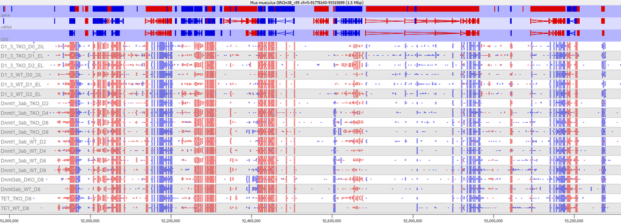

Reads mostly in exons, opposite strand stranded librarly, low technical duplication

New Probe Set:exons (54682 probes)

Feature generator using gene split into exons duplicates removed Over feature from 0-0

Probes Quantitated

Read Count Quantitation using All Reads correcting for total count per million reads log transformed

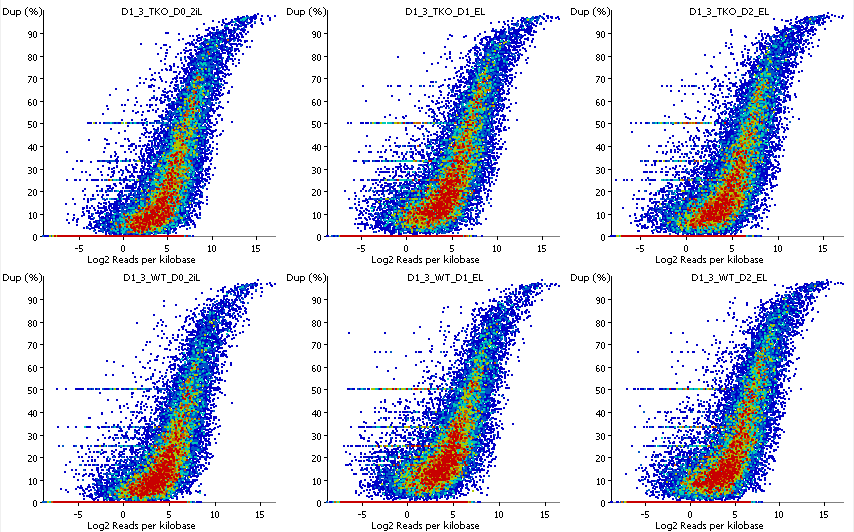

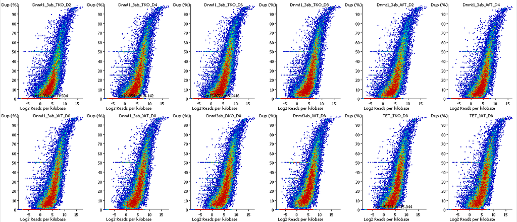

Indeed, essentially no technical duplication.

### RNAseq QC plot

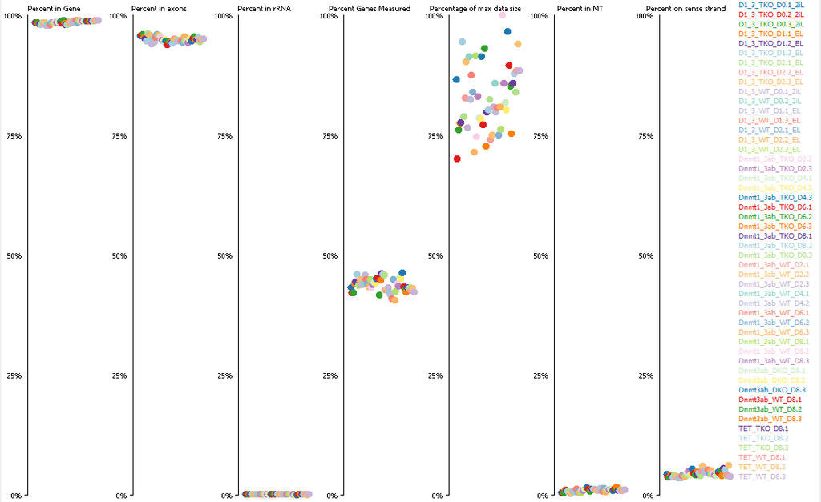

Looking very good

### Checking knockouts

New Probe Set:All Probes (27157 probes)

Wiggle probes

Probes Quantitated

Base Pair Quantitation using All Reads correcting for total count to largest store

### Dnmt1

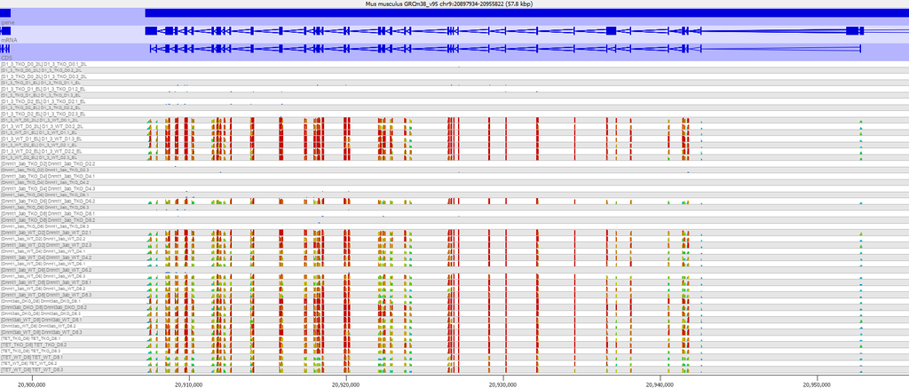

### Dnmt3a

New Probe Set:All Probes (69713 probes)

Wiggle probes

Probes Quantitated

Base Pair Quantitation using All Reads correcting for total count to largest store

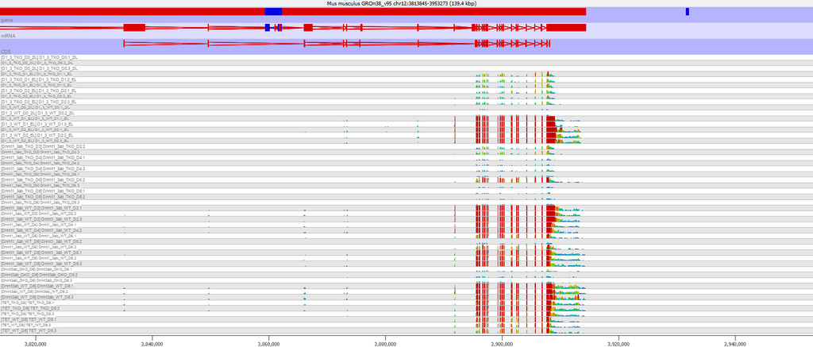

### Dnmt3b

New Probe Set:All Probes (26776 probes)

Wiggle probes

Probes Quantitated

Base Pair Quantitation using All Reads correcting for total count to largest store

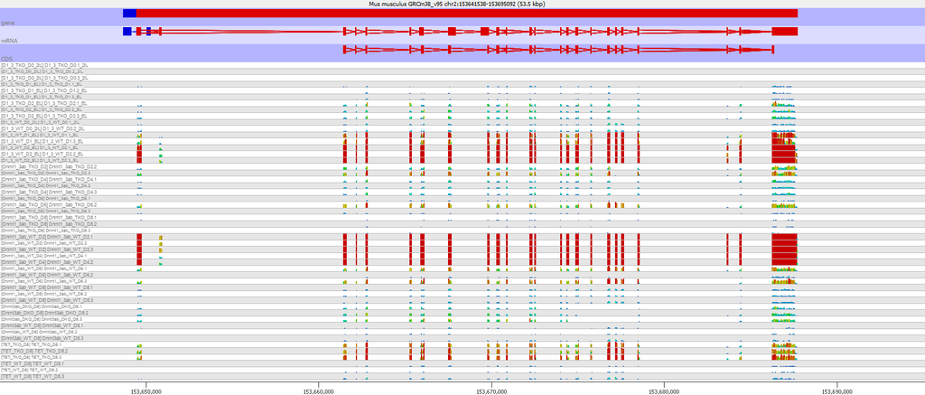

Dnmt1_3ab_TKO_D6.2 is really a WT!

Dnmt1_3ab_WT_D6.2 is really a KO!

### Tets

New Probe Set:All Probes (63445 probes)

Wiggle probes

Probes Quantitated

Base Pair Quantitation using All Reads correcting for total count to largest store

### Tet1

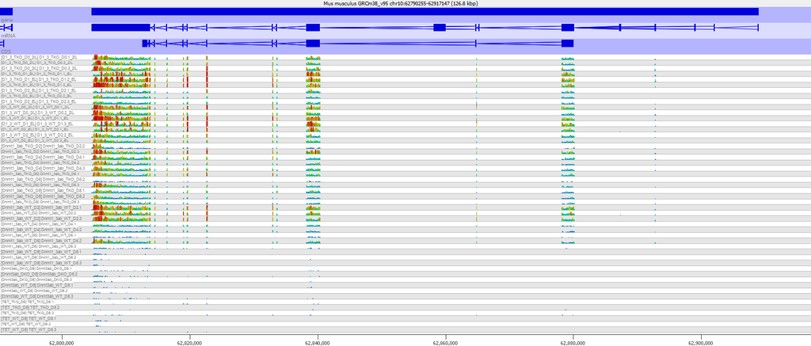

Not much Tet1 on D8 of EB differentiation

### Tet3

New Probe Set:All Probes (56362 probes)

Wiggle probes

Probes Quantitated

Base Pair Quantitation using All Reads correcting for total count to largest store

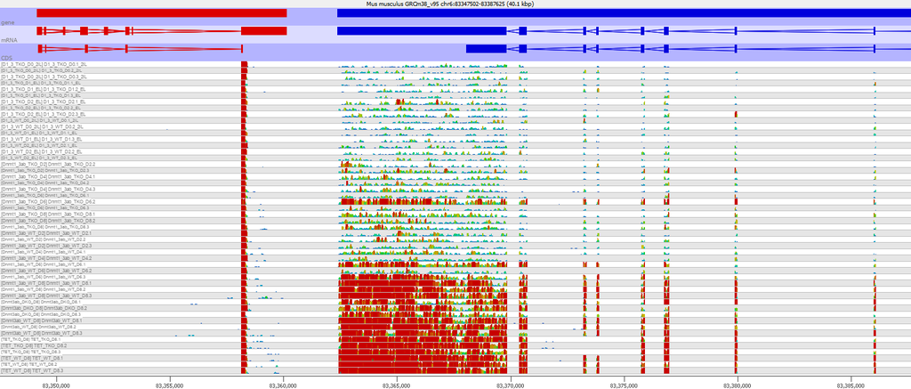

As expected two exons missing in the TET TKO

New Probe Set:All Probes (46305 probes)

Wiggle probes

Probes Quantitated

Base Pair Quantitation using All Reads correcting for total count to largest store

### Tet2

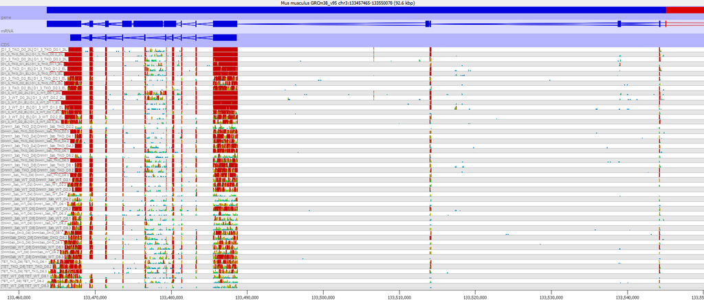

as expected, two exons missing in the Tet TKO